# PWD_raport

Aleksandra Romanowicz

24 stycznia 2018

# Zakupy w Black Friday

## Raport przygotowany na zajęcia Prezentacja i Wizualizacja Danych prowadzone przez dr Mariusza Rafało

### Źródło danych i cel projektu

W pierwszym kroku zostaną wczytane dane pochodzące z https://www.kaggle.com/mehdidag/black-friday.

Zbiór zawiera informacje o zakupionych kategoriach produktów i cechach osób kupujących - 537 577 transakcji dokonanych przez 5 891 użytkowników. Zawarte zmiene to:  
- User_ID - ID użytkownika, który dokonał zakupu,  
- Product_ID - ID zakupionego produktu,  
- Gender - płeć kupującego, przyjmuje wartości F i M,  
- Age - wiek kupującego, zmienna kategoryzująca przyjmująca 7 poziomów,  
- Occupation - zawód kupującego, zmienna kategoryzująca przyjmująca 21 poziomów; niestety w danych źródłowych nie ujawniono informacji, co kryje się pod poszczególnymi kategoriami,  
- City_Category - kategoria miasta kupującego, zmienna przyjmuje 3 poziomy (A, B i C); niestety w danych źródłowych nie ujawniono informacji, co kryje się pod poszczególnymi kategoriami,  
- Stay_In_Current_City_Years - liczba lat, od ilu kupujący mieszka w obecnym mieście, zmienna kategoryzująca przyjmująca 5 poziomów,  
- Marital_Status - stan cywilny, zmienna przyjmuje wartość 0 lub 1,  
- Product_Category_1, Product_Category_2, Product_Category_3 - kategoria kupowanego produktu, danemu ID produktu odpowiada jedna kombinacja tych trzech parametrów; niestety w danych źródłowych nie ujawniono informacji, co kryje się pod poszczególnymi kategoriami,  
- Purchase - wydana kwota w dolarach.

Celem analizy jest zdefiniowanie cech użytkowników, które wpływają na wysokość dokonywanych zakupów.

### Wstępna analiza danych

```r
rm(list=ls())
d<-read.csv('C:/Users/Aleksandra Romanowic/Downloads/black-friday/BlackFriday.csv', header=TRUE, sep=",")
str(d)
```

```
## 'data.frame':    537577 obs. of  12 variables:
##  $ User_ID                   : int  1000001 1000001 1000001 1000001 1000002 1000003 1000004 1000004 1000004 1000005 ...
##  $ Product_ID                : Factor w/ 3623 levels "P00000142","P00000242",..: 671 2375 851 827 2733 1830 1744 3319 3597 2630 ...
##  $ Gender                    : Factor w/ 2 levels "F","M": 1 1 1 1 2 2 2 2 2 2 ...
##  $ Age                       : Factor w/ 7 levels "0-17","18-25",..: 1 1 1 1 7 3 5 5 5 3 ...
##  $ Occupation                : int  10 10 10 10 16 15 7 7 7 20 ...
##  $ City_Category             : Factor w/ 3 levels "A","B","C": 1 1 1 1 3 1 2 2 2 1 ...
##  $ Stay_In_Current_City_Years: Factor w/ 5 levels "0","1","2","3",..: 3 3 3 3 5 4 3 3 3 2 ...
##  $ Marital_Status            : int  0 0 0 0 0 0 1 1 1 1 ...
##  $ Product_Category_1        : int  3 1 12 12 8 1 1 1 1 8 ...
##  $ Product_Category_2        : int  NA 6 NA 14 NA 2 8 15 16 NA ...
##  $ Product_Category_3        : int  NA 14 NA NA NA NA 17 NA NA NA ...
##  $ Purchase                  : int  8370 15200 1422 1057 7969 15227 19215 15854 15686 7871 ...
```

Po wczytaniu zmieniamy typy zmiennych Occupation oraz Purchase odpowiednio na factor oraz numeric.

```r
d$Occupation <- factor(d$Occupation)
d$Purchase <- as.numeric(as.character(d$Purchase))
```

Każdy z rekordów to zakup danego towaru przez danego użytkownika - w celu zanalizowania danych zagregowanych stworzono tabele pomocnicze przypisujące do użytkownika jego parametry (m.in. wiek, miasto, suma wydanych pieniędzy), a także tabela przypisująca parametry do danego produktu - jego kod kategorii oraz sumaryczną kwotę wydanych przez kupujących pieniędzy. Dla łatwiejszej prezentacji danych, kwoty sumaryczne zostaną wyrażone w tysiącach dolarów (w dokumentacji zbioru danych nie zostało określone, jakiego typu są to produkty, stąd wysokość zakupów może dziwić, ale nie uniemożliwia przeprowadzenia analizy).

```r
d_userInfo <- sqldf('SELECT User_ID, Gender, Age, Occupation, City_Category, Stay_In_Current_City_Years, Marital_Status, sum(Purchase)/1000 as PurchasePerUserK from d group by User_ID')
d_productInfo <- sqldf('SELECT Product_ID, Product_Category_1, Product_Category_2, Product_Category_3, sum(Purchase)/1000 as PurchasePerProductK from d group by Product_ID')
```

Przed dalszą analizą warto sprawdzić, co oznacza zmienna Marital_Status, która nie została w pełni objaśniona dla danych źródłowych. Z wcześniejszego podsumowania wiemy, że przyjmuje ona wartości 0 i 1, prawdopodobnie w zależności od tego, czy użytkownik jest w związku małżeńskim.

```r
summary(d_userInfo$Marital_Status)
```

```
##    Min. 1st Qu.  Median    Mean 3rd Qu.    Max.
##    0.00    0.00    0.00    0.42    1.00    1.00
```

W całej grupie użytkowników, dla 42% użytkowników zmienna Marital_Status przyjęła wartość 1. Sprawdźmy, jak to wygląda w grupie osób poniżej 17 roku życia:

```r
summary(d_userInfo[d_userInfo$Age=='0-17',]$Marital_Status)
```

```
##    Min. 1st Qu.  Median    Mean 3rd Qu.    Max.
##       0       0       0       0       0       0
```

W tej grupie dla 100% użytkowników zmienna Marital_Status przyjmuje wartość 0. Mamy prawo założyć, że wartość 1 oznacza osoby, które weszły w związek małżeński.

Dzięki zabiegowi agregującemu dane łatwo jest dostrzec pierwsze wnioski w zadanym zbiorze danych, np. wykres kołowy prezentujący strukturę kupujących według płci (dla wszystkich zawartych transakcji) prezentuje się w następujący sposób:

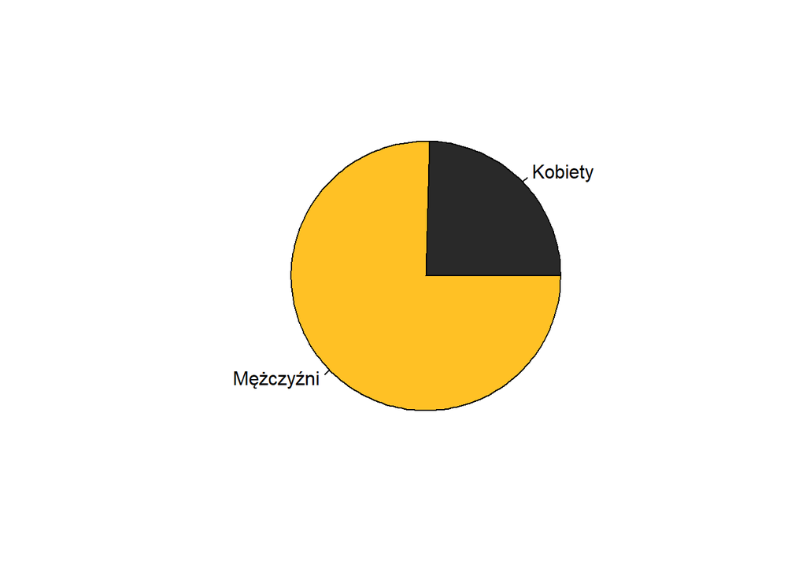

```r
pie(table(d$Gender), col=c('gray16', 'goldenrod1'), labels=c("Kobiety", "Mężczyźni"))
```

Biorąc pod uwagę wszystkie transakcje, co czwarty kupujący jest kobietą (a ściślej - co czwarty produkt został kupiony przez kobietę).

Analogiczny wykres dla zagregowanych danych o kupujących (w zbiorze, w którym każdy użytkownik występuje tylko raz niezależnie od liczby transakcji) prezentuje się następująco:

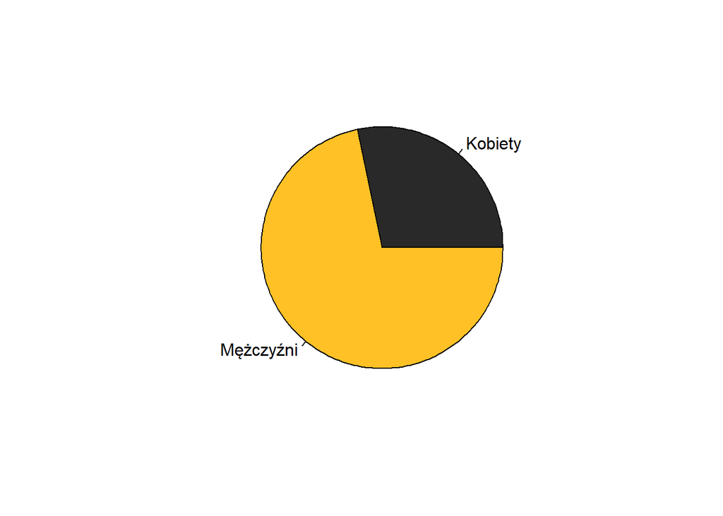

```r
pie(table(d_userInfo$Gender), col=c('gray16', 'goldenrod1'), labels=c("Kobiety", "Mężczyźni"))
```

Zwiększony udział kobiet w grupie kupujących może prowadzić do pierwszego wniosku, że mężczyźni są większą grupą kupujących oraz, że kupują więcej (większą liczbę produktów per użytkownik). Nie można jeszcze wnioskować nic o ilości wydawanych pieniędzy.

W kolejnym kroku warto zobaczyć, jak prezentują się wydatki w poszczególnych grupach.

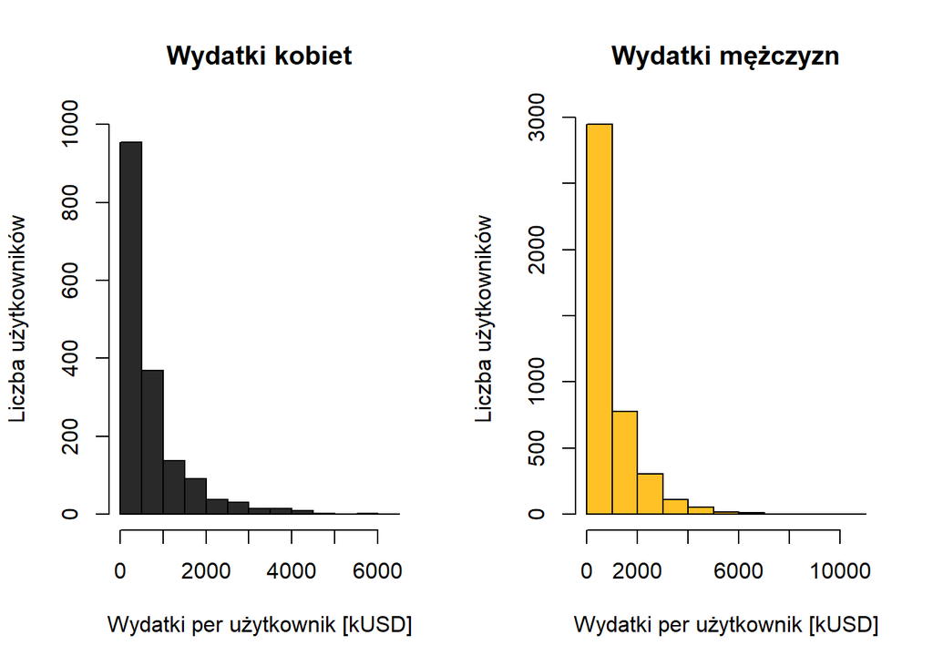

```r
par(mfrow=c(1,2))

hist(d_userInfo[d_userInfo$Gender=="F",]$PurchasePerUserK, main="Wydatki kobiet", xlab= 'Wydatki per użytkownik [kUSD]', ylab = "Liczba użytkowników", col = 'gray16', ylim=c(0,1000) )


hist(d_userInfo[d_userInfo$Gender=="M",]$PurchasePerUserK, main="Wydatki mężczyzn", xlab= 'Wydatki per użytkownik [kUSD]', ylab = "Liczba użytkowników", col = 'goldenrod1' )
```

W obu grupach wydatki wydają się mieć podobny rozkład - najwięcej osób kupuje za najniższą sumaryczną kwotę i wraz ze wzrostem poziomu wydatków, maleje liczba osób w grupie.

Porównajmy jeszcze wykresy gęstości:

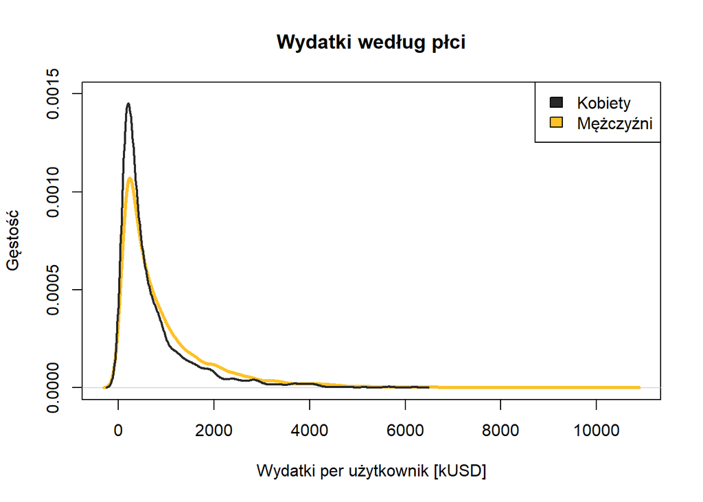

```r
plot(density(d_userInfo[d_userInfo$Gender=="M",]$PurchasePerUserK),
     main="Wydatki według płci",
     xlab= 'Wydatki per użytkownik [kUSD]',
     ylab = "Gęstość",
     col = 'goldenrod1',
     lwd=3,
     ylim=c(0,0.0015))


lines(density(d_userInfo[d_userInfo$Gender=="F",]$PurchasePerUserK), col = 'gray16', lwd=2)

legend("topright",
       fill=c("gray16", "goldenrod1"),
       legend = c("Kobiety", "Mężczyźni"))
```

Z wykresu możemy odczytać, że wydatki kobiet są bardziej skupione wokół jednej wartości, a wydatki mężczyzn są relatywnie bardziej zróżnicowane.

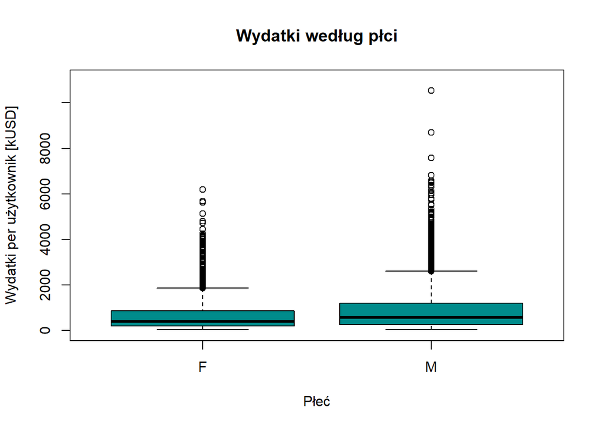

```r
plot(d_userInfo$Gender, d_userInfo$PurchasePerUserK, xlab = 'Płeć', ylab='Wydatki per użytkownik [kUSD]', col='cyan4', ylim = c(0,11000), main = 'Wydatki według płci')
```

Wśród kobiet obserwuje się niższą medianę wydatków oraz wartość minimalną. Zgodnie z histogramami i wykresem gęstości, różnica między pierwszym i trzecim kwartylem również jest widocznie niższa niż w grupie mężczyzn (co potwierdza poniższe podsumowanie):

```r
summary(d_userInfo[d_userInfo$Gender=="F",]$PurchasePerUserK)
```

```
##    Min. 1st Qu.  Median    Mean 3rd Qu.    Max.
##   44.11  200.25  398.18  699.05  863.76 6186.50
```

```r
summary(d_userInfo[d_userInfo$Gender=="M",]$PurchasePerUserK)
```

```
##     Min.  1st Qu.   Median     Mean  3rd Qu.     Max.
##    45.55   254.67   565.92   911.96  1193.53 10536.78
```

Następnie przyjrzyjmy się rozkładowi wydatków w poszczególnych grupach zawodowych

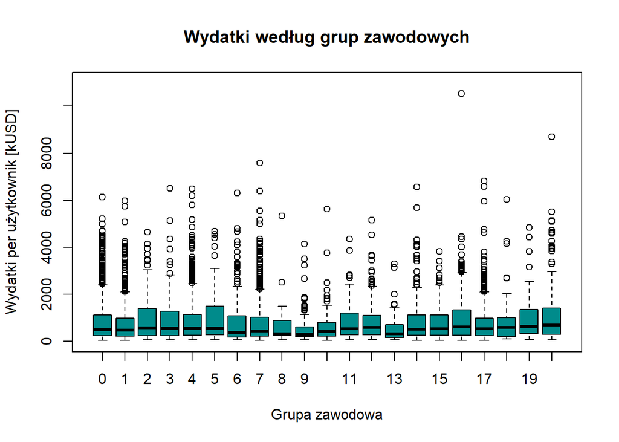

```r
plot(d_userInfo$Occupation, d_userInfo$PurchasePerUserK, xlab = 'Grupa zawodowa', ylab='Wydatki per użytkownik [kUSD]', col='cyan4', ylim = c(0,11000), main = 'Wydatki według grup zawodowych')
```

Grupy zawodowe cechują się zbliżoną medianą oraz dolnym kwartylem wydatków. W niemal każdej z grup można zaobserwować liczne obserwacje odstające.

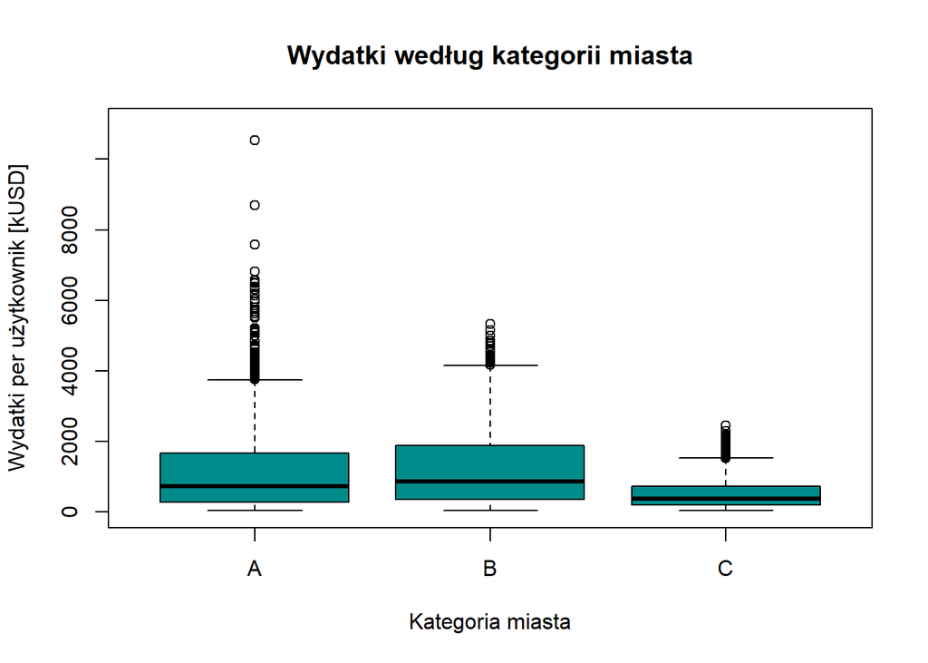

```r
plot(d_userInfo$City_Category, d_userInfo$PurchasePerUserK, xlab = 'Kategoria miasta', ylab='Wydatki per użytkownik [kUSD]', col='cyan4', ylim = c(0,11000), main = 'Wydatki według kategorii miasta')
```

Poza większą liczbą obserwacji odstających, grupy miast A i B nie różnią się znacząco pod względem wydatków na użytkownika. W grupie C obserwowane jest znaczne zmniejszenie różnicy między wartością maksymalną i minimalną wydatków, a także między pierwszym i trzecim kwartylem, co świadczy o zbliżeniu wartości wydatków dla kolejnych użytkowników do mediany.

```r
summary(d_userInfo[d_userInfo$City_Category=="A",]$PurchasePerUserK)
```

```
##     Min.  1st Qu.   Median     Mean  3rd Qu.     Max.
##    45.55   281.78   730.13  1239.87  1672.67 10536.78
```

```r
summary(d_userInfo[d_userInfo$City_Category=="B",]$PurchasePerUserK)
```

```
##    Min. 1st Qu.  Median    Mean 3rd Qu.    Max.
##   44.43  355.72  873.35 1220.52 1876.03 5327.35
```

```r
summary(d_userInfo[d_userInfo$City_Category=="C",]$PurchasePerUserK)
```

```
##    Min. 1st Qu.  Median    Mean 3rd Qu.    Max.
##   44.11  196.89  378.04  522.00  727.08 2456.08
```

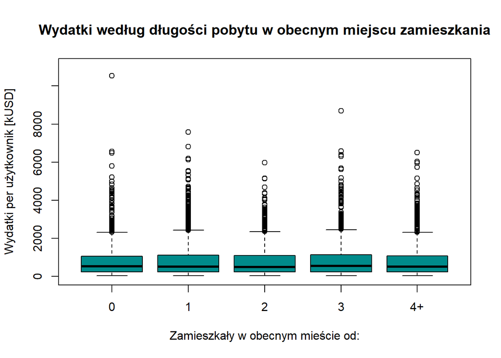

```r
plot(d_userInfo$Stay_In_Current_City_Years, d_userInfo$PurchasePerUserK, xlab = 'Zamieszkały w obecnym mieście od:', ylab='Wydatki per użytkownik [kUSD]', col='cyan4', ylim = c(0,11000), main = 'Wydatki według długości pobytu w obecnym miejscu zamieszkania')
```

### Analiza czynników determinujących wysokość zakupów

#### Regresja liniowa

Po wstępnej wizualizacji danych sprzedażowych postanowiłam zbadać czynniki wpływające na wysokość zakupów dokonywanych przez użytkownika tworząc model regresji liniowej. Zaczęłam od wszystkich zmiennych dostępnych w zbiorze.

```r
#colnames(d_userInfo)

m1 <- lm(PurchasePerUserK ~ Age + Stay_In_Current_City_Years + Occupation + Marital_Status + Gender + City_Category,
          data=d_userInfo)

summary(m1)
```

```
##
## Call:
## lm(formula = PurchasePerUserK ~ Age + Stay_In_Current_City_Years +
##     Occupation + Marital_Status + Gender + City_Category, data = d_userInfo)
##
## Residuals:
##     Min      1Q  Median      3Q     Max
## -1448.2  -490.2  -166.9   310.7  9008.1
##
## Coefficients:
##                              Estimate Std. Error t value Pr(>|t|)
## (Intercept)                  1013.303    105.896   9.569  < 2e-16 ***
## Age18-25                       57.252     97.485   0.587 0.557028
## Age26-35                      174.849     97.933   1.785 0.074248 .
## Age36-45                      141.490     99.611   1.420 0.155537
## Age46-50                      111.119    104.309   1.065 0.286791
## Age51-55                       35.300    105.293   0.335 0.737447
## Age55+                        -81.530    108.745  -0.750 0.453441
## Stay_In_Current_City_Years1   -22.861     36.045  -0.634 0.525963
## Stay_In_Current_City_Years2   -44.221     39.834  -1.110 0.266995
## Stay_In_Current_City_Years3    11.535     41.173   0.280 0.779359
## Stay_In_Current_City_Years4+  -18.016     41.822  -0.431 0.666641
## Occupation1                   -54.043     50.177  -1.077 0.281508
## Occupation2                   -64.718     62.601  -1.034 0.301262
## Occupation3                    99.919     73.543   1.359 0.174308
## Occupation4                   -44.449     49.168  -0.904 0.366021
## Occupation5                    75.743     87.466   0.866 0.386544
## Occupation6                   -24.188     65.810  -0.368 0.713230
## Occupation7                   -81.604     47.014  -1.736 0.082666 .
## Occupation8                    32.466    209.854   0.155 0.877057
## Occupation9                   -70.622     98.368  -0.718 0.472822
## Occupation10                 -109.455    104.121  -1.051 0.293197
## Occupation11                 -131.269     82.477  -1.592 0.111530
## Occupation12                 -189.792     55.150  -3.441 0.000583 ***
## Occupation13                 -134.343     86.972  -1.545 0.122479
## Occupation14                  -48.207     59.636  -0.808 0.418921
## Occupation15                 -119.974     79.380  -1.511 0.130744
## Occupation16                  134.247     65.236   2.058 0.039647 *
## Occupation17                 -127.431     51.004  -2.498 0.012501 *
## Occupation18                   68.346    109.682   0.623 0.533223
## Occupation19                  149.311    107.639   1.387 0.165449
## Occupation20                   64.839     61.271   1.058 0.289995
## Marital_Status                 -2.774     24.198  -0.115 0.908749
## GenderM                       239.626     25.952   9.234  < 2e-16 ***
## City_CategoryB                -13.149     33.690  -0.390 0.696328
## City_CategoryC               -696.871     30.983 -22.492  < 2e-16 ***
## ---
## Signif. codes:  0 '***' 0.001 '**' 0.01 '*' 0.05 '.' 0.1 ' ' 1
##
## Residual standard error: 853.4 on 5856 degrees of freedom
## Multiple R-squared:  0.1682, Adjusted R-squared:  0.1634
## F-statistic: 34.83 on 34 and 5856 DF,  p-value: < 2.2e-16
```

Model nie wyjaśnia modelu w wysokim stopniu - większość zmiennych jest nieistotna statystycznie z p-value na poziomie 5%, a skorygowane R^2 wynosi 16,34% (16% zmienności modelu zostało wyjaśnione przez wybrane zmienne objaśniające).

Spróbujmy z innym modelem - usuwam zmienną Maritial_Status oraz Stay_In_Current_City_Years (wszystkie ich kategorie są nieistotne).

```r
m2 <- lm(PurchasePerUserK ~ Age  + Occupation  + Gender + City_Category,
          data=d_userInfo)

summary(m2)
```

```
##
## Call:
## lm(formula = PurchasePerUserK ~ Age + Occupation + Gender + City_Category,
##     data = d_userInfo)
##
## Residuals:
##     Min      1Q  Median      3Q     Max
## -1433.9  -489.1  -164.7   311.0  9026.1
##
## Coefficients:
##                Estimate Std. Error t value Pr(>|t|)
## (Intercept)      996.94     102.37   9.738  < 2e-16 ***
## Age18-25          57.33      97.31   0.589 0.555805
## Age26-35         174.22      97.48   1.787 0.073955 .
## Age36-45         141.02      99.17   1.422 0.155070
## Age46-50         109.46     102.95   1.063 0.287718
## Age51-55          33.12     103.89   0.319 0.749880
## Age55+           -82.54     107.65  -0.767 0.443275
## Occupation1      -54.80      50.14  -1.093 0.274463
## Occupation2      -64.30      62.58  -1.028 0.304217
## Occupation3       98.31      73.51   1.337 0.181172
## Occupation4      -46.28      49.12  -0.942 0.346195
## Occupation5       75.40      87.41   0.863 0.388419
## Occupation6      -25.22      65.76  -0.384 0.701287
## Occupation7      -82.32      46.98  -1.752 0.079792 .
## Occupation8       32.11     209.70   0.153 0.878310
## Occupation9      -71.52      98.31  -0.727 0.466988
## Occupation10    -110.85     104.06  -1.065 0.286786
## Occupation11    -132.39      82.44  -1.606 0.108357
## Occupation12    -189.61      55.12  -3.440 0.000585 ***
## Occupation13    -138.20      86.85  -1.591 0.111611
## Occupation14     -47.46      59.56  -0.797 0.425563
## Occupation15    -122.31      79.32  -1.542 0.123120
## Occupation16     133.23      65.19   2.044 0.041027 *
## Occupation17    -126.88      50.97  -2.489 0.012835 *
## Occupation18      65.19     109.63   0.595 0.552127
## Occupation19     150.34     107.59   1.397 0.162353
## Occupation20      63.94      61.24   1.044 0.296487
## GenderM          239.50      25.94   9.233  < 2e-16 ***
## City_CategoryB   -14.15      33.67  -0.420 0.674394
## City_CategoryC  -697.97      30.96 -22.544  < 2e-16 ***
## ---
## Signif. codes:  0 '***' 0.001 '**' 0.01 '*' 0.05 '.' 0.1 ' ' 1
##
## Residual standard error: 853.2 on 5861 degrees of freedom
## Multiple R-squared:  0.1678, Adjusted R-squared:  0.1637
## F-statistic: 40.75 on 29 and 5861 DF,  p-value: < 2.2e-16
```

Uzyskałam niewielką poprawę skorygowanego R^2 (do 16,37%).  
Wydaje się, że zmienna Age może przyjmować różne oszacowania w zależności od płci kupującego. Sprawdźmy jeszcze trzeci model:

```r
m3 <- lm(PurchasePerUserK ~ Age + Occupation + Gender + City_Category + Age*Gender,
          data=d_userInfo)

summary(m3)
```

```
##
## Call:
## lm(formula = PurchasePerUserK ~ Age + Occupation + Gender + City_Category +
##     Age * Gender, data = d_userInfo)
##
## Residuals:
##     Min      1Q  Median      3Q     Max
## -1445.9  -494.8  -160.5   308.5  9022.6
##
## Coefficients:
##                  Estimate Std. Error t value Pr(>|t|)
## (Intercept)       1042.53     131.12   7.951  2.2e-15 ***
## Age18-25            30.05     136.79   0.220 0.826143
## Age26-35            97.58     132.61   0.736 0.461875
## Age36-45            86.77     136.27   0.637 0.524292
## Age46-50            31.22     142.74   0.219 0.826853
## Age51-55            20.01     146.61   0.136 0.891437
## Age55+             -14.43     155.40  -0.093 0.926017
## Occupation1        -51.93      50.17  -1.035 0.300633
## Occupation2        -65.72      62.62  -1.049 0.294017
## Occupation3         99.98      73.58   1.359 0.174225
## Occupation4        -46.45      49.17  -0.945 0.344837
## Occupation5         75.99      87.44   0.869 0.384844
## Occupation6        -23.23      65.81  -0.353 0.724101
## Occupation7        -81.12      47.03  -1.725 0.084603 .
## Occupation8         26.67     209.77   0.127 0.898850
## Occupation9        -63.96      98.83  -0.647 0.517518
## Occupation10      -113.47     104.50  -1.086 0.277578
## Occupation11      -132.44      82.49  -1.606 0.108423
## Occupation12      -192.38      55.17  -3.487 0.000491 ***
## Occupation13      -135.38      86.90  -1.558 0.119324
## Occupation14       -47.27      59.61  -0.793 0.427793
## Occupation15      -121.97      79.35  -1.537 0.124336
## Occupation16       133.68      65.22   2.050 0.040433 *
## Occupation17      -127.94      51.02  -2.508 0.012182 *
## Occupation18        63.25     109.67   0.577 0.564158
## Occupation19       154.01     107.63   1.431 0.152527
## Occupation20        64.51      61.31   1.052 0.292716
## GenderM            171.77     121.15   1.418 0.156291
## City_CategoryB     -13.82      33.68  -0.410 0.681567
## City_CategoryC    -698.63      30.98 -22.552  < 2e-16 ***
## Age18-25:GenderM    43.06     134.99   0.319 0.749721
## Age26-35:GenderM   109.96     128.69   0.854 0.392906
## Age36-45:GenderM    79.41     133.72   0.594 0.552651
## Age46-50:GenderM   116.95     144.43   0.810 0.418119
## Age51-55:GenderM    20.80     148.42   0.140 0.888552
## Age55+:GenderM     -88.57     157.40  -0.563 0.573689
## ---
## Signif. codes:  0 '***' 0.001 '**' 0.01 '*' 0.05 '.' 0.1 ' ' 1
##
## Residual standard error: 853.3 on 5855 degrees of freedom
## Multiple R-squared:  0.1685, Adjusted R-squared:  0.1635
## F-statistic: 33.89 on 35 and 5855 DF,  p-value: < 2.2e-16
```

Model niestety nie uległ poprawie (skorygowane R^2 = 16,35%), w dodatku nowostworzone zmienne są nieistotne.

Sprawdźmy, czy reszty modelu m2 (wybranego jako najlepiej dopasowanego) mają rozkład normalny.

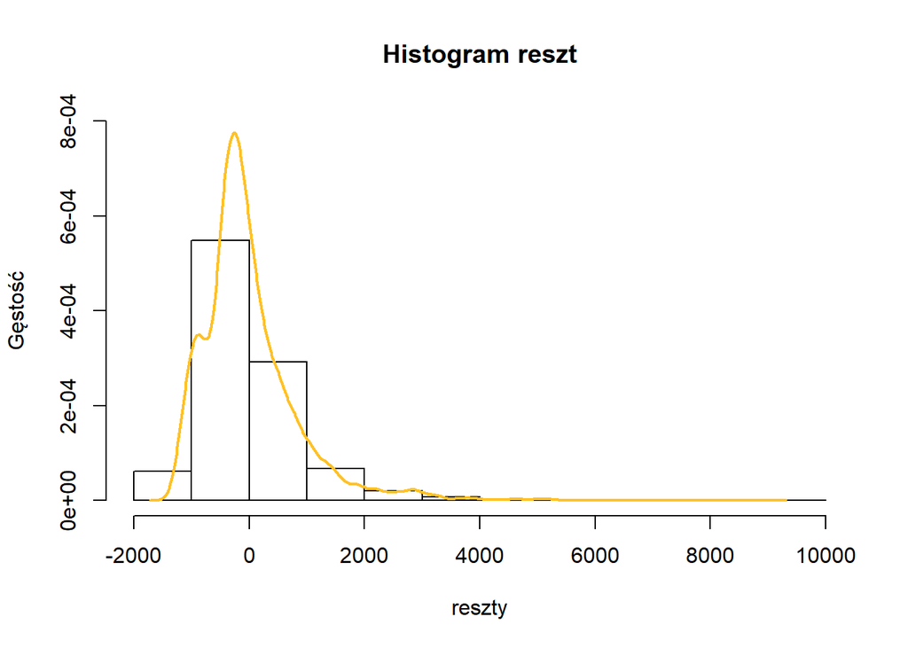

```r
reszty = residuals(m2)
hist(reszty, prob=TRUE, ylim=c(0,0.0008), main='Histogram reszt', ylab='Gęstość', xlab='reszty')
lines(density(reszty), col="goldenrod1", lwd=2)
```

Jak widać analiza czynników wplywających na wysokość zakupów poszczególnych użytkowników nie jest zbyt dokładna - jedynie 16% zmienności udało się wyjaśnić. Nie wszystkie zmienne są istotne statystycznie, stąd oszacowania parametrów mogą być przeszacowane lub niedoszacowane. Ze zmiennych istotnych nasilniejszym wpływem cechuje się zmienna odpowiadająca za kategorię C miasta - użytkownicy w tych miast wydawali nawet 697.97 tys. mniej. Drugim silnym wpływem jest płeć - mężczyźni wydają o 239 tys. więcej. Pozostałe zmienne istotne to trzy kategorie zawodów - 12, 16 oraz 17.

#### Regresja logistyczna

Sprobuję podejść do problemu w inny sposób i podzielić użytkownikóW na robiących większe i mniejsze zakupy (na podstawie mediany w grupie)

```r
medianPurchase <- median(d_userInfo$PurchasePerUserK, na.rm=FALSE)
d_userInfo$largePurchase <- 2
d_userInfo$largePurchase[d_userInfo$PurchasePerUserK>=medianPurchase] <-1
d_userInfo$largePurchase[d_userInfo$PurchasePerUserK<medianPurchase] <-0
summary(d_userInfo$largePurchase)
```

```
##    Min. 1st Qu.  Median    Mean 3rd Qu.    Max.
##  0.0000  0.0000  1.0000  0.5001  1.0000  1.0000
```

Każdemu użytkownikowi udało się przyporządkować zmienną zero-jedynkową largePurchase (1 dla zakupów powyżej mediany w grupie). Dla zmiennej zero-jedynkowej możemy przeprowadzić regresję logistyczną. W tym celu dzielimy zbiór na treningowy i testowy:

```r
set.seed(1456)
s <- sample.int(nrow(d_userInfo), floor(0.75*nrow(d_userInfo)), replace= FALSE)
d_userInfo.train<- d_userInfo[s,]
d_userInfo.test<-d_userInfo[-s,]
```

```r
set.seed(1456)
s <- sample.int(nrow(d), floor(0.75*nrow(d)), replace= FALSE)
d.train<- d[s,]
d.test<-d[-s,]
```

```r
glm1 <- glm(largePurchase ~ Age + Stay_In_Current_City_Years + Occupation + Marital_Status + Gender + City_Category,
          data=d_userInfo.train,
          family= binomial)
summary(glm1)
```

```
##
## Call:
## glm(formula = largePurchase ~ Age + Stay_In_Current_City_Years +
##     Occupation + Marital_Status + Gender + City_Category, family = binomial,
##     data = d_userInfo.train)
##
## Deviance Residuals:
##     Min       1Q   Median       3Q      Max
## -1.7988  -1.0614  -0.5596   1.0675   2.0438
##
## Coefficients:
##                                Estimate Std. Error z value Pr(>|z|)
## (Intercept)                   0.0249510  0.2986294   0.084   0.9334
## Age18-25                      0.0098993  0.2754866   0.036   0.9713
## Age26-35                      0.2136062  0.2770851   0.771   0.4408
## Age36-45                      0.1188336  0.2815110   0.422   0.6729
## Age46-50                     -0.0466643  0.2942234  -0.159   0.8740
## Age51-55                     -0.1030253  0.2969110  -0.347   0.7286
## Age55+                       -0.7051313  0.3115095  -2.264   0.0236 *
## Stay_In_Current_City_Years1  -0.0975730  0.1029047  -0.948   0.3430
## Stay_In_Current_City_Years2  -0.1095204  0.1137754  -0.963   0.3357
## Stay_In_Current_City_Years3   0.0065357  0.1169735   0.056   0.9554
## Stay_In_Current_City_Years4+ -0.0252072  0.1188473  -0.212   0.8320
## Occupation1                   0.0340523  0.1415823   0.241   0.8099
## Occupation2                   0.2374531  0.1768615   1.343   0.1794
## Occupation3                   0.2328076  0.2099009   1.109   0.2674
## Occupation4                   0.0422229  0.1389364   0.304   0.7612
## Occupation5                   0.1126563  0.2460877   0.458   0.6471
## Occupation6                  -0.2304986  0.1869817  -1.233   0.2177
## Occupation7                  -0.1245940  0.1321641  -0.943   0.3458
## Occupation8                  -0.7698845  0.7070759  -1.089   0.2762
## Occupation9                  -0.2884159  0.2892423  -0.997   0.3187
## Occupation10                 -0.1754599  0.2944631  -0.596   0.5513
## Occupation11                  0.1664170  0.2305712   0.722   0.4704
## Occupation12                  0.1896834  0.1570310   1.208   0.2271
## Occupation13                  0.1669141  0.2509231   0.665   0.5059
## Occupation14                 -0.0161954  0.1680667  -0.096   0.9232
## Occupation15                  0.0503972  0.2198530   0.229   0.8187
## Occupation16                  0.5080896  0.1860029   2.732   0.0063 **
## Occupation17                 -0.0004633  0.1454445  -0.003   0.9975
## Occupation18                  0.2146979  0.3017378   0.712   0.4768
## Occupation19                  0.6082711  0.2984557   2.038   0.0415 *
## Occupation20                  0.2247354  0.1723269   1.304   0.1922
## Marital_Status                0.0229642  0.0681184   0.337   0.7360
## GenderM                       0.4414858  0.0742702   5.944 2.78e-09 ***
## City_CategoryB                0.2061243  0.0949617   2.171   0.0300 *
## City_CategoryC               -0.8611860  0.0862710  -9.982  < 2e-16 ***
## ---
## Signif. codes:  0 '***' 0.001 '**' 0.01 '*' 0.05 '.' 0.1 ' ' 1
##
## (Dispersion parameter for binomial family taken to be 1)
##
##     Null deviance: 6124.6  on 4417  degrees of freedom
## Residual deviance: 5727.3  on 4383  degrees of freedom
## AIC: 5797.3
##
## Number of Fisher Scoring iterations: 4
```

Modele logistyczne będziemy porównywać pod względem kryterium informacyjnego Akaike, AIC (im niższa wartość, tym model jest lepiej dopasowany).  
Podobnie jak w modelach liniowych, zmienna Marital_Status oraz Stay_In_Current_City_Years są nieistotne statystycznie we wszystkich kategoriach. Usuwamy je z modelu:

```r
glm2 <- glm(largePurchase ~ Age  + Occupation  + Gender + City_Category,
          data=d_userInfo.train,
          family= binomial)
summary(glm2)
```

```
##
## Call:
## glm(formula = largePurchase ~ Age + Occupation + Gender + City_Category,
##     family = binomial, data = d_userInfo.train)
##
## Deviance Residuals:
##     Min       1Q   Median       3Q      Max
## -1.8198  -1.0562  -0.5489   1.0737   2.0253
##
## Coefficients:
##                  Estimate Std. Error z value Pr(>|z|)
## (Intercept)    -0.0251780  0.2897805  -0.087  0.93076
## Age18-25        0.0157053  0.2750233   0.057  0.95446
## Age26-35        0.2202623  0.2758999   0.798  0.42467
## Age36-45        0.1257486  0.2803470   0.449  0.65376
## Age46-50       -0.0328357  0.2904510  -0.113  0.90999
## Age51-55       -0.0932179  0.2931893  -0.318  0.75053
## Age55+         -0.6931126  0.3087908  -2.245  0.02479 *
## Occupation1     0.0300878  0.1414553   0.213  0.83156
## Occupation2     0.2335180  0.1767147   1.321  0.18635
## Occupation3     0.2245735  0.2097570   1.071  0.28433
## Occupation4     0.0372489  0.1387477   0.268  0.78834
## Occupation5     0.1107133  0.2462440   0.450  0.65299
## Occupation6    -0.2347630  0.1868589  -1.256  0.20898
## Occupation7    -0.1270410  0.1320020  -0.962  0.33584
## Occupation8    -0.7723523  0.7077932  -1.091  0.27518
## Occupation9    -0.2902779  0.2888018  -1.005  0.31484
## Occupation10   -0.1842231  0.2943080  -0.626  0.53135
## Occupation11    0.1631213  0.2304737   0.708  0.47909
## Occupation12    0.1842420  0.1568584   1.175  0.24016
## Occupation13    0.1578798  0.2506193   0.630  0.52872
## Occupation14   -0.0177094  0.1678631  -0.105  0.91598
## Occupation15    0.0420653  0.2194007   0.192  0.84796
## Occupation16    0.5042881  0.1858146   2.714  0.00665 **
## Occupation17    0.0007673  0.1453594   0.005  0.99579
## Occupation18    0.2094343  0.3013095   0.695  0.48700
## Occupation19    0.6062378  0.2982125   2.033  0.04206 *
## Occupation20    0.2233195  0.1721449   1.297  0.19454
## GenderM         0.4407537  0.0742274   5.938 2.89e-09 ***
## City_CategoryB  0.2019632  0.0948552   2.129  0.03324 *
## City_CategoryC -0.8633285  0.0861783 -10.018  < 2e-16 ***
## ---
## Signif. codes:  0 '***' 0.001 '**' 0.01 '*' 0.05 '.' 0.1 ' ' 1
##
## (Dispersion parameter for binomial family taken to be 1)
##
##     Null deviance: 6124.6  on 4417  degrees of freedom
## Residual deviance: 5729.8  on 4388  degrees of freedom
## AIC: 5789.8
##
## Number of Fisher Scoring iterations: 4
```

Spróbujemy, podobnie jak ostatnio, sprawdzić również korelacje zmiennych płeć i wiek.

```r
glm3 <- glm(largePurchase ~ Age  + Occupation  + Gender + City_Category + Age*Gender,
          data=d_userInfo.train,
          family= binomial)
summary(glm3)
```

```
##
## Call:
## glm(formula = largePurchase ~ Age + Occupation + Gender + City_Category +
##     Age * Gender, family = binomial, data = d_userInfo.train)
##
## Deviance Residuals:
##     Min       1Q   Median       3Q      Max
## -1.8063  -1.0468  -0.5515   1.0664   2.0234
##
## Coefficients:
##                   Estimate Std. Error z value Pr(>|z|)
## (Intercept)      -0.300242   0.391570  -0.767  0.44322
## Age18-25          0.316881   0.407381   0.778  0.43666
## Age26-35          0.532287   0.395810   1.345  0.17869
## Age36-45          0.497770   0.404621   1.230  0.21862
## Age46-50          0.017898   0.424809   0.042  0.96639
## Age51-55          0.181491   0.432091   0.420  0.67446
## Age55+           -0.410255   0.479442  -0.856  0.39217
## Occupation1       0.033863   0.141559   0.239  0.81094
## Occupation2       0.239097   0.176964   1.351  0.17666
## Occupation3       0.210658   0.210116   1.003  0.31607
## Occupation4       0.034751   0.138759   0.250  0.80225
## Occupation5       0.113196   0.246514   0.459  0.64610
## Occupation6      -0.230923   0.187101  -1.234  0.21712
## Occupation7      -0.127044   0.132116  -0.962  0.33625
## Occupation8      -0.766377   0.706933  -1.084  0.27833
## Occupation9      -0.312082   0.290524  -1.074  0.28273
## Occupation10     -0.164934   0.295936  -0.557  0.57730
## Occupation11      0.155265   0.230586   0.673  0.50072
## Occupation12      0.189771   0.157014   1.209  0.22681
## Occupation13      0.157396   0.251213   0.627  0.53096
## Occupation14     -0.023873   0.167818  -0.142  0.88688
## Occupation15      0.049798   0.219759   0.227  0.82073
## Occupation16      0.498700   0.185810   2.684  0.00728 **
## Occupation17     -0.003423   0.145452  -0.024  0.98122
## Occupation18      0.205657   0.301260   0.683  0.49482
## Occupation19      0.587682   0.298404   1.969  0.04891 *
## Occupation20      0.227684   0.172378   1.321  0.18656
## GenderM           0.828130   0.372985   2.220  0.02640 *
## City_CategoryB    0.201013   0.094923   2.118  0.03421 *
## City_CategoryC   -0.864824   0.086239 -10.028  < 2e-16 ***
## Age18-25:GenderM -0.419708   0.409924  -1.024  0.30590
## Age26-35:GenderM -0.435267   0.392920  -1.108  0.26796
## Age36-45:GenderM -0.520340   0.405028  -1.285  0.19890
## Age46-50:GenderM -0.054335   0.435051  -0.125  0.90061
## Age51-55:GenderM -0.384647   0.442600  -0.869  0.38481
## Age55+:GenderM   -0.395158   0.493223  -0.801  0.42303
## ---
## Signif. codes:  0 '***' 0.001 '**' 0.01 '*' 0.05 '.' 0.1 ' ' 1
##
## (Dispersion parameter for binomial family taken to be 1)
##
##     Null deviance: 6124.6  on 4417  degrees of freedom
## Residual deviance: 5725.5  on 4382  degrees of freedom
## AIC: 5797.5
##
## Number of Fisher Scoring iterations: 4
```

Jak dotąd drugi model jest najlepiej dopasowany do danych, sprawdźmy jak modele radzą sobie z prognozowaniem.

```r
predict.glm_1 <- predict(glm1, newdata=d_userInfo.test, type = "response")
predict.glm1 <- predict.glm_1
predict.glm1[predict.glm_1>0.5] <-1
predict.glm1[predict.glm_1<=0.5] <-0
```

Tworzymy tablicę pomyłek (confusion matrix), która wskazuje, jak wiele wartości 0 i 1 zostało prawidłowo przewidzianych:

```r
conf.matrix.glm1 <- confusionMatrix(table(predict.glm1, as.numeric(d_userInfo.test$largePurchase)))
conf.matrix.glm1$table
```

```
##
## predict.glm1   0   1
##            0 487 310
##            1 241 435
```

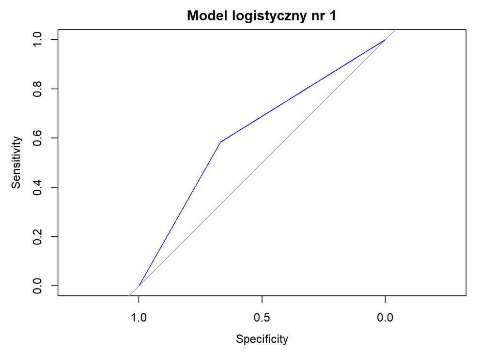

```r
roc.glm1 <- roc(as.numeric(d_userInfo.test$largePurchase),predict.glm1, direction="<")
plot(roc.glm1,col="blue", lwd=1, main="Model logistyczny nr 1")
```

Te same operacje wykonujemy dla modelu 2.

```r
predict.glm_2 <- predict(glm2, newdata=d_userInfo.test, type = "response")
predict.glm2 <- predict.glm_2
predict.glm2[predict.glm_2>0.5] <-1
predict.glm2[predict.glm_2<=0.5] <-0
```

```r
conf.matrix.glm2 <- confusionMatrix(table(predict.glm2, as.numeric(d_userInfo.test$largePurchase)))
conf.matrix.glm2$table
```

```
##
## predict.glm2   0   1
##            0 493 310
##            1 235 435
```

Względem modelu 1 zmniejszyła się liczba fałszywie pozytywnych wartości.

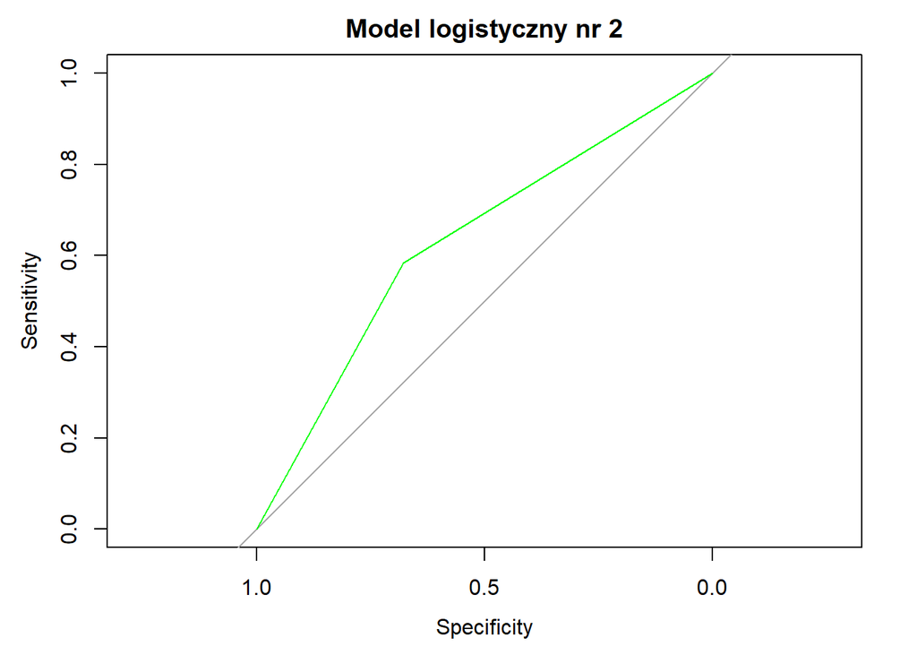

```r
roc.glm2 <- roc(as.numeric(d_userInfo.test$largePurchase),predict.glm2, direction="<")
plot(roc.glm2,col="green", lwd=1, main="Model logistyczny nr 2")
```

Kolejna iteracja - model 3.

```r
predict.glm_3 <- predict(glm3, newdata=d_userInfo.test, type = "response")
predict.glm3 <- predict.glm_3
predict.glm3[predict.glm_3>0.5] <-1
predict.glm3[predict.glm_3<=0.5] <-0
```

```r
conf.matrix.glm3 <- confusionMatrix(table(predict.glm3, as.numeric(d_userInfo.test$largePurchase)))
conf.matrix.glm3$table
```

```
##
## predict.glm3   0   1
##            0 496 317
##            1 232 428
```

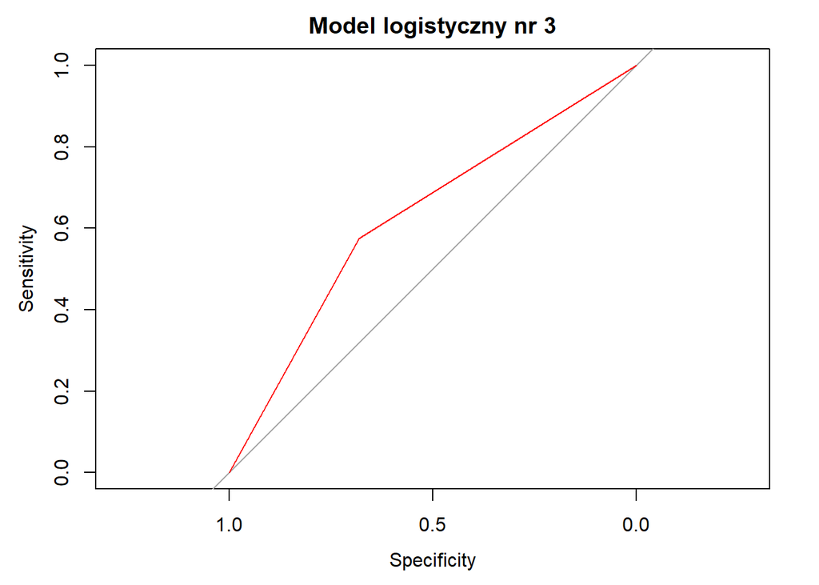

```r
roc.glm3 <- roc(as.numeric(d_userInfo.test$largePurchase),predict.glm3, direction="<")
plot(roc.glm3,col="red", lwd=1, main="Model logistyczny nr 3")
```

Nanieśmy wszystkie krzywe na jeden wykres w celu znalezienia najlepiej dopasowanego modelu.

[figure not shown]

```r
plot(roc.glm3,col="red", lwd=0.1, main="Model logistyczny - porównanie")
lines(roc.glm1, col="green", lwd=0.1)
lines(roc.glm1, col="blue", lwd=0.1)
legend("bottomright",
       fill=c("red", "green", "blue"),
       legend = c("Model nr 3", "Model nr 2", "Model nr 1"))
```

Niestety modele są bardzo zbliżone - musimy wspomóc się wyliczonymi statystykami.

```r
roc1 <- auc(roc.glm1)
roc2 <- auc(roc.glm2)
roc3 <- auc(roc.glm3)

cat("Wielkość pola pod krzywą (AUC) dla modelu 1 wynosi: ", roc1, "\n")
```

```
## Wielkość pola pod krzywą (AUC) dla modelu 1 wynosi:  0.6264243
```

```r
cat("Wielkość pola pod krzywą (AUC) dla modelu 2 wynosi: ", roc2, "\n")
```

```
## Wielkość pola pod krzywą (AUC) dla modelu 2 wynosi:  0.6305452
```

```r
cat("Wielkość pola pod krzywą (AUC) dla modelu 3 wynosi: ", roc3, "\n")
```

```
## Wielkość pola pod krzywą (AUC) dla modelu 3 wynosi:  0.6279077
```

```r
exp(cbind(Odd_Ratio = coef(glm3), confint(glm3)))
```

```
##                  Odd_Ratio      2.5 %    97.5 %
## (Intercept)      0.7406388 0.33827449 1.5810448
## Age18-25         1.3728386 0.62280328 3.0945422
## Age26-35         1.7028218 0.79095073 3.7576736
## Age36-45         1.6450481 0.75079972 3.6909021
## Age46-50         1.0180587 0.44578260 2.3706914
## Age51-55         1.1990032 0.51741333 2.8307165
## Age55+           0.6634813 0.25826304 1.7028793
## Occupation1      1.0344431 0.78370062 1.3652984
## Occupation2      1.2701016 0.89872661 1.7994895
## Occupation3      1.2344895 0.81799970 1.8662508
## Occupation4      1.0353614 0.78888594 1.3592926
## Occupation5      1.1198518 0.69116315 1.8208392
## Occupation6      0.7938003 0.54884321 1.1436548
## Occupation7      0.8806952 0.67962829 1.1409187
## Occupation8      0.4646937 0.09735043 1.7135795
## Occupation9      0.7319216 0.40825405 1.2806993
## Occupation10     0.8479494 0.47321614 1.5145575
## Occupation11     1.1679676 0.74402093 1.8404290
## Occupation12     1.2089729 0.88917742 1.6460040
## Occupation13     1.1704586 0.71271439 1.9113811
## Occupation14     0.9764101 0.70251975 1.3568992
## Occupation15     1.0510584 0.68331912 1.6194837
## Occupation16     1.6465786 1.14584235 2.3754856
## Occupation17     0.9965828 0.74927490 1.3254263
## Occupation18     1.2283317 0.67979709 2.2262131
## Occupation19     1.7998122 1.00985706 3.2690660
## Occupation20     1.2556886 0.89658403 1.7630956
## GenderM          2.2890348 1.11484640 4.8383321
## City_CategoryB   1.2226408 1.01490164 1.4725088
## City_CategoryC   0.4211257 0.35541372 0.4984071
## Age18-25:GenderM 0.6572386 0.29019792 1.4539530
## Age26-35:GenderM 0.6470920 0.29496814 1.3832089
## Age36-45:GenderM 0.5943187 0.26482273 1.3017325
## Age46-50:GenderM 0.9471145 0.39908201 2.2054343
## Age51-55:GenderM 0.6806909 0.28270113 1.6090117
## Age55+:GenderM   0.6735736 0.25543125 1.7751493
```

#### Drzewo decyzyjne

Pobocznym problemem biznesowym, który można spróbować rozwiązać korzystając z tego zbioru danych jest hipotetyczna sytuacja, gdzie prowadzący sklep internetowy nie może ze 100% pewnością zweryfikować wieku użytkownika, a chciałby dostarczyć mu różne treści w zależności od grupy wiekowej (sytuacja może nastąpić, gdy wiek jest zmienną deklaratywną, niepopartą żadnym dokumentem). Wówczas na podstawie pozostałych parametrów można spróbować określić, do jakiej kategorii należy przypisać konsumenta.

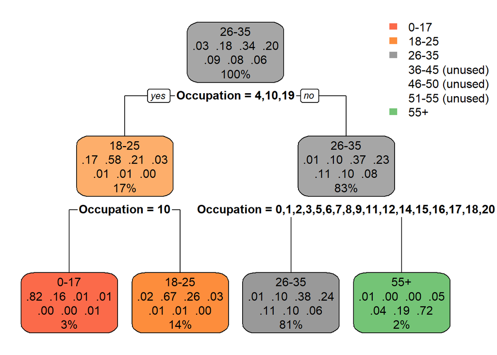

```r
model.dt <- rpart(Age ~ largePurchase + Gender + Stay_In_Current_City_Years + Occupation + Marital_Status  + City_Category, data=d_userInfo.train)
rpart.plot(model.dt)
```

Jedynymi zmiennymi, które algorytm wziął pod uwagę jest zawód użytkownika. Kategoria zawodu nr 10 przyporządkowuje użytkownikowi wiek w przedziale 0-25lat. Ta kategoria może oznaczać zawód uczeń/student, spróbujmy więc usunąć ją z analizy.

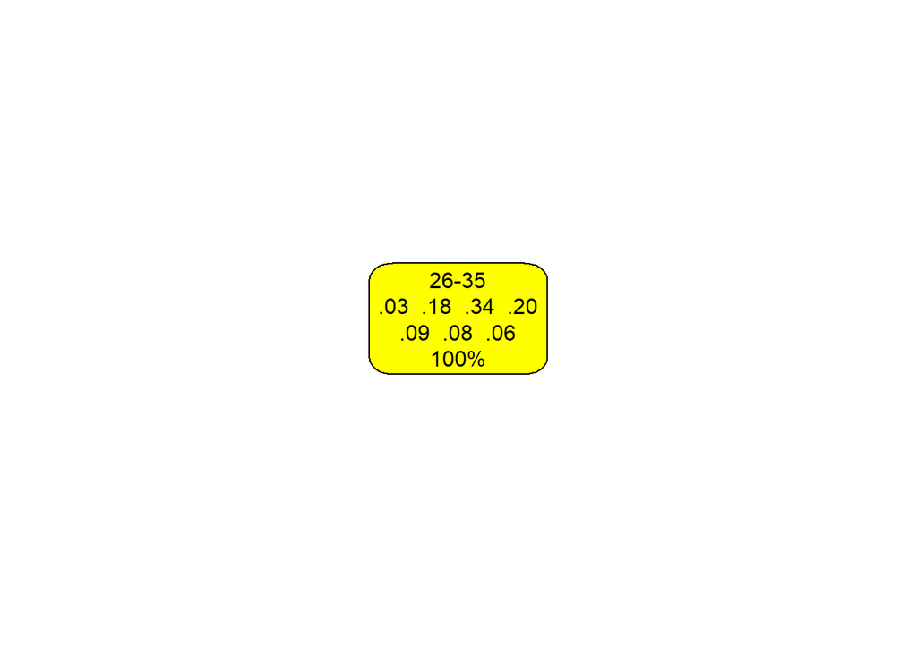

```r
model.dt_2 <- rpart(Age ~ largePurchase + Gender + Stay_In_Current_City_Years  + Marital_Status  + City_Category, data=d_userInfo.train)
rpart.plot(model.dt_2, box.palette = "yellow")
```

Niestety, usunięcie tej zmiennej nie pozwala na interpretację wyniku. Sprawdźmy jeszcze, jaką głębokość optymalnie powinien mieć pierwszy z modeli.

```r
printcp(model.dt)
```

```
##
## Classification tree:
## rpart(formula = Age ~ largePurchase + Gender + Stay_In_Current_City_Years +
##     Occupation + Marital_Status + City_Category, data = d_userInfo.train)
##
## Variables actually used in tree construction:
## [1] Occupation
##
## Root node error: 2895/4418 = 0.65527
##
## n= 4418
##
##         CP nsplit rel error  xerror     xstd
## 1 0.093610      0   1.00000 1.00000 0.010912
## 2 0.030743      1   0.90639 0.90639 0.011275
## 3 0.026943      2   0.87565 0.87565 0.011354
## 4 0.010000      3   0.84870 0.84870 0.011407
```

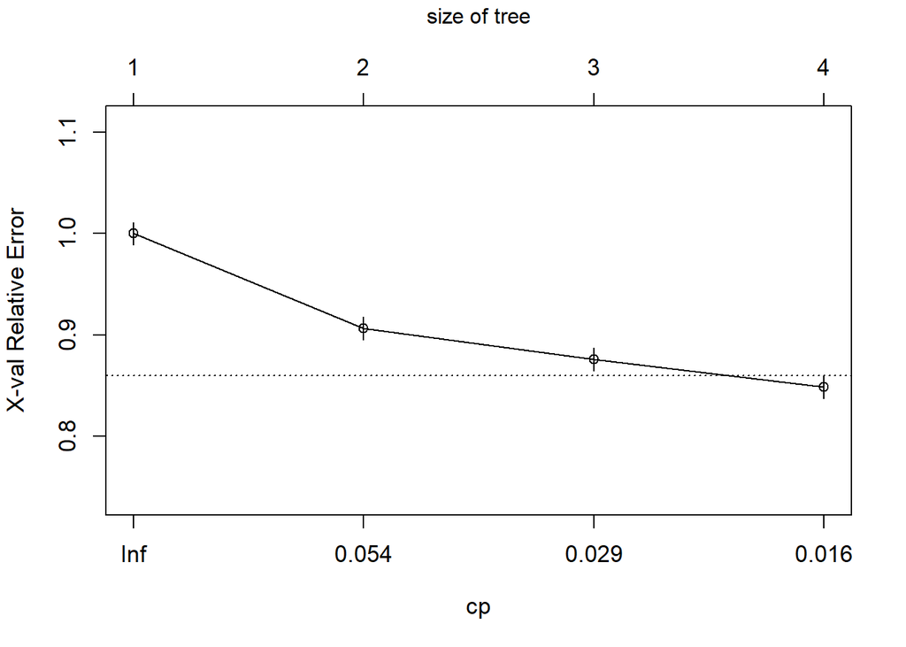

```r
plotcp(model.dt, cex.lab=1.1, cex.axis=1.1)
```

Niestety, powyższy zbiór danych nie jest pomocny w przyporządkowywaniu użytkowników do kategorii wiekowej przy pomocy drzewa decyzyjnego.

### Podsumowanie

Głównym celem powyższej analizy było zbadanie, jaki konsument dokona zakupów na wysoką kwotę. Zarówno według modelu regresji liniowej, jak i logistycznej dla nowoutworzonej zmiennej, czynnikami nasilniej wpływającymi na wysokość zakupów (lub fakt zrobienia zakupów wyższych niż mediana w grupie) jest płeć konsumenta (mężczyźni wydają więcej) oraz kategoria miasta. Według modelu regresji liniowej, najwyższe zakupy robią osoby z miast kat. A, następnie B i C. Model regresji logistycznej jest zgodny co do kat. C jako miast z użytkownikami z najniższym prawdopodobieństwem zrobienia dużych zakupów, jednak B stawia wyżej niż A.